# NASP-ESOL - Social Network Analysis

## 4.2 Eigenvector centrality

Example data

```r
(net1 <- read_rds(here("data", "cent_example_1.rds")))
```

```
## This graph was created by an old(er) igraph version.
## ℹ Call `igraph::upgrade_graph()` on it to use with the current igraph version.
## For now we convert it on the fly...
```

```
## IGRAPH e0b5591 U--- 11 17 --
## + attr: cent (v/n)
## + edges from e0b5591:
##  [1] 1--11 2-- 4 3-- 5 3--11 4-- 8 5-- 9 5--11 6-- 7 6-- 8 6--10 6--11 7-- 9
## [13] 7--10 7--11 8-- 9 8--10 9--10
```

If we plot the network by visualizing degree centrality, who is the most central node?

```r
V(net1)$names <- 1:vcount(net1)

my_plot <-
  net1 %>%
  ggraph(layout = "auto") +
  geom_edge_link(
    color = "grey",
    width = .5
  ) +
  geom_node_text(aes(label = V(net1)$names))
```

```
## Using "stress" as default layout
```

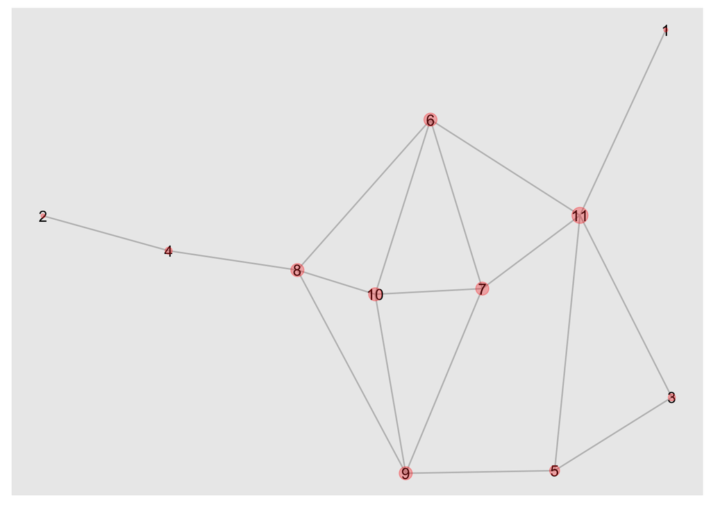

```r
my_plot +
  geom_node_point(
    size = igraph::degree(net1),
    color = "red",
    alpha = .3
  )
```

Who would you choose for a policy intervention to let something diffuse more rapidly?

We need to calculate *eigenvector centrality* (see slides)

```r
eigen_centrality(net1)
```

[output not shown]

[output cut: 12 more lines]

```
##
## $options$iter
## [1] 4
##
## $options$nconv
## [1] 1
##
## $options$numop
## [1] 19
##
## $options$numopb
## [1] 0
##
## $options$numreo
## [1] 13
```

Retrieving the vector only (scaled values)

```r
eigen_centrality(net1)$vector
```

```
##  [1] 0.2259630 0.0645825 0.3786244 0.2415182 0.5709057 0.9846544 1.0000000
##  [8] 0.8386195 0.9113529 0.9986474 0.8450304
```

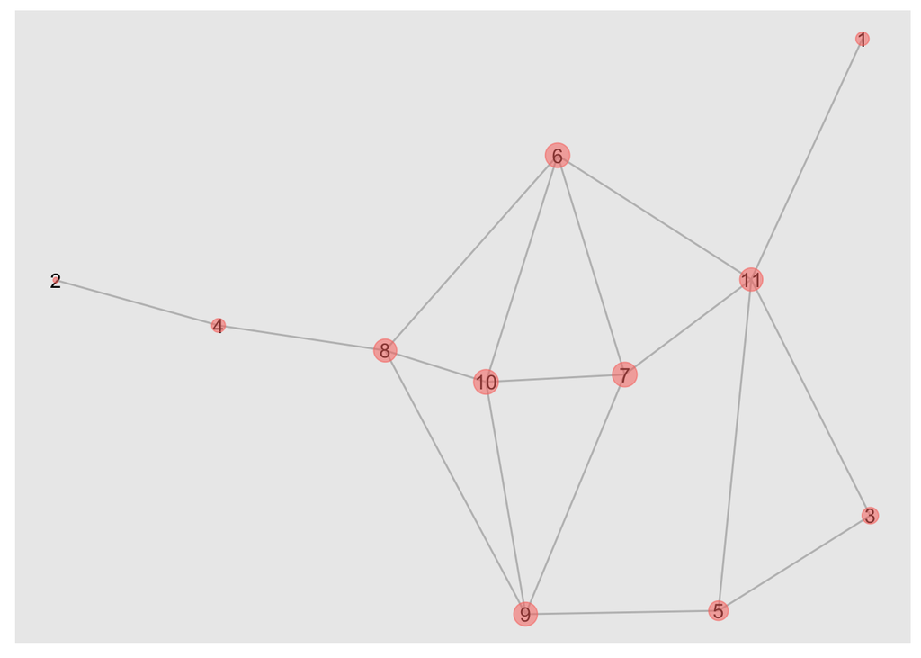

```r
my_plot +
  geom_node_point(
    aes(
      size = eigen_centrality(net1)$vector,
      color = "red",
      alpha = .5
    ),
    show.legend = FALSE
  )
```

Compare degree centrality and eigenvector centrality

```r
tibble(
  node = 1:vcount(net1),
  degree_cent = igraph::degree(net1),
  eigen_cent = eigen_centrality(net1)$vector
) %>%
  arrange(desc(degree_cent))
```

| node | degree_cent | eigen_cent |
| --- | --- | --- |
| 11 | 5 | 0.8450304 |
| 6 | 4 | 0.9846544 |
| 7 | 4 | 1.0000000 |
| 8 | 4 | 0.8386195 |
| 9 | 4 | 0.9113529 |
| 10 | 4 | 0.9986474 |
| 5 | 3 | 0.5709057 |
| 3 | 2 | 0.3786244 |
| 4 | 2 | 0.2415182 |
| 1 | 1 | 0.2259630 |

[output cut: 1 more lines]

## 4.3 Betweenness centrality

Calculate

```r
(btw_net1 <- betweenness(net1, normalized = T))
```

```
##  [1] 0.00000000 0.00000000 0.00000000 0.20000000 0.08518519 0.21851852
##  [7] 0.05925926 0.36296296 0.16296296 0.02962963 0.32592593
```

Plot

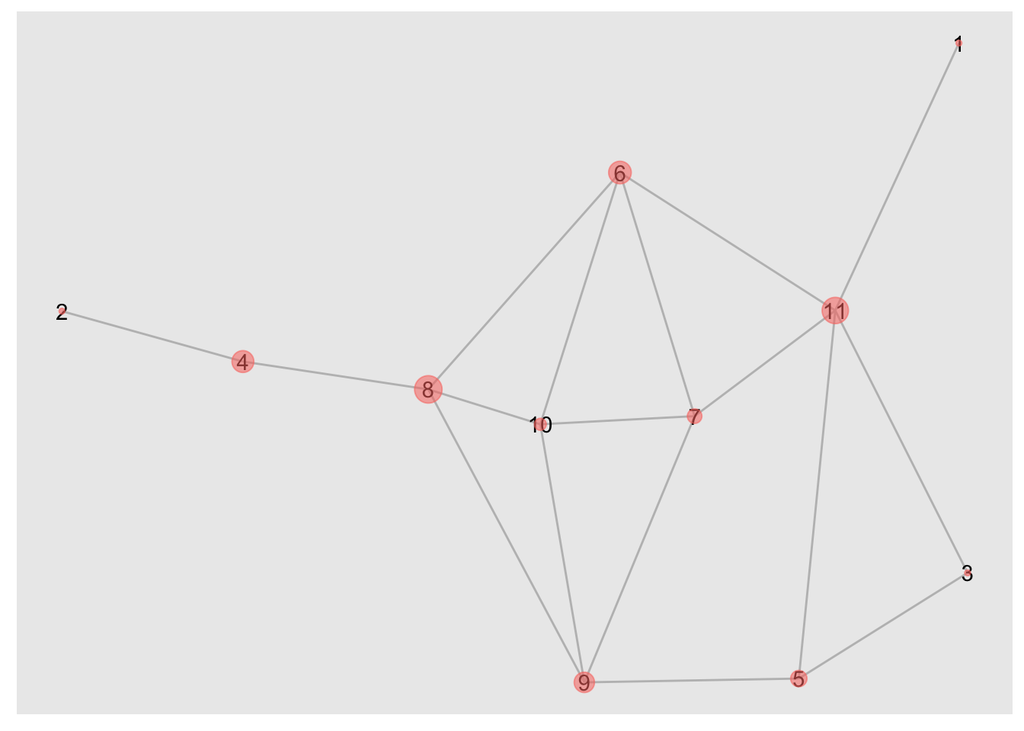

```r
my_plot +
  geom_node_point(
    aes(
      size = btw_net1,
      color = "red",
      alpha = .5
    ),
    show.legend = FALSE
  )
```

Compare degree centrality, eigenvector centrality, and betweenness centrality

```r
tibble(
  node = 1:vcount(net1),
  degree_cent = igraph::degree(net1),
  eigen_cent = eigen_centrality(net1)$vector,
  btw_cent = btw_net1
) %>%
  arrange(desc(degree_cent))
```

| node | degree_cent | eigen_cent | btw_cent |
| --- | --- | --- | --- |
| 11 | 5 | 0.8450304 | 0.32592593 |
| 6 | 4 | 0.9846544 | 0.21851852 |
| 7 | 4 | 1.0000000 | 0.05925926 |
| 8 | 4 | 0.8386195 | 0.36296296 |
| 9 | 4 | 0.9113529 | 0.16296296 |
| 10 | 4 | 0.9986474 | 0.02962963 |
| 5 | 3 | 0.5709057 | 0.08518519 |
| 3 | 2 | 0.3786244 | 0.00000000 |
| 4 | 2 | 0.2415182 | 0.20000000 |
| 1 | 1 | 0.2259630 | 0.00000000 |

[output cut: 1 more lines]

## 4.4 Clustering

- *clustering* is one of the most important processes in network evolution
- the outcome of clustering is the formation of *cohesive subgroups*

How many clusters? Discuss

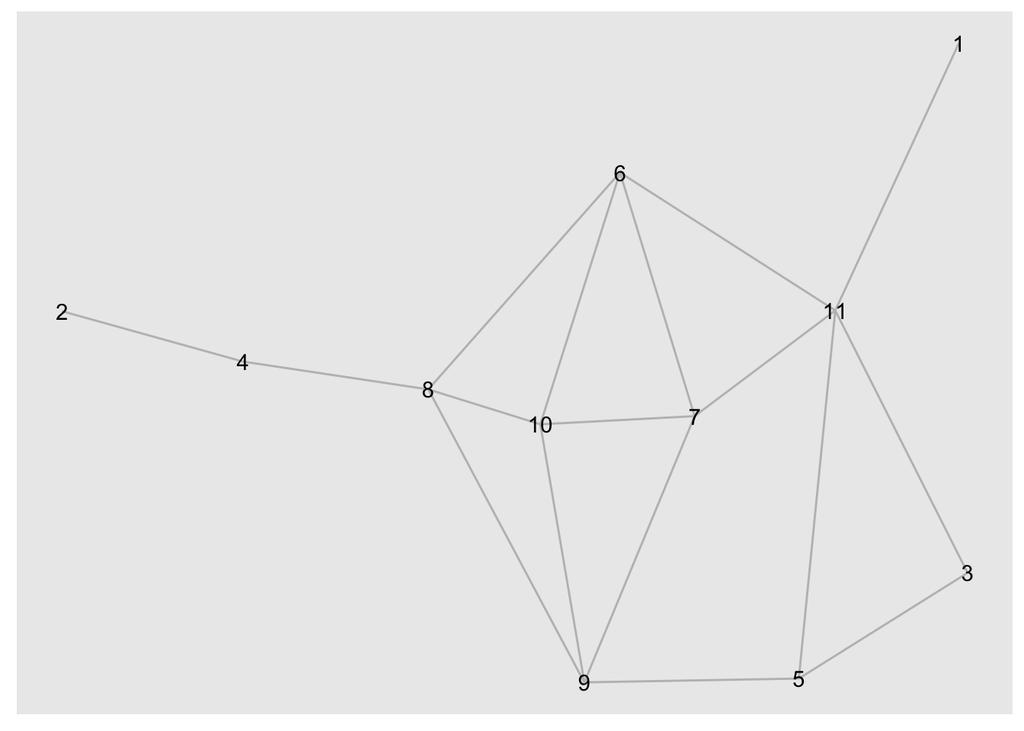

```r
my_plot
```

- Cliques (considers undirected networks with reciprocated ties only, otherwise a clique should be maximal reciprocation)
- List

It doesn’t make much sense. At least 4

```r
cliques(net1, min = 3)
```

```
## [[1]]
## + 3/11 vertices, from e0b5591:
## [1]  6  8 10
##
## [[2]]
## + 3/11 vertices, from e0b5591:
## [1]  8  9 10
##
## [[3]]
## + 3/11 vertices, from e0b5591:
## [1]  6  7 10
##
## [[4]]
## + 3/11 vertices, from e0b5591:
## [1]  6  7 11
##
## [[5]]
## + 3/11 vertices, from e0b5591:
## [1]  7  9 10
##
## [[6]]
## + 3/11 vertices, from e0b5591:
## [1]  3  5 11
```

```r
cliques(collab_net, min = 6)
```

```
## [[1]]
## + 6/29 vertices, named, from c98a2b1:
## [1] 3  10 19 20 23 27
##
## [[2]]
## + 6/29 vertices, named, from c98a2b1:
## [1] 6  10 13 15 20 23
##
## [[3]]
## + 6/29 vertices, named, from c98a2b1:
## [1] 3  6  9  19 20 23
##
## [[4]]
## + 6/29 vertices, named, from c98a2b1:
## [1] 3  6  10 19 20 23
##
## [[5]]
## + 6/29 vertices, named, from c98a2b1:
## [1] 6  10 13 15 16 20
```

- It’s more useful to avoid *a priori* definitions
- Bottom-up classification of social/political reality
  - categories are concepts that we analysts (or lay people) apply to single objects by deduction
  - however, they emerge from induction-based inferences by analogy (abstract away from idiosyncratic elements) (Harrison C. White)
  - this is what *community detection* algorithms do: partitioning a graph into dense network regions loosely connected to each other
- Several algorithms can do that: some of them aim to optimize the partition *modularity*, *Q* (i.e., the number of within-group edges compared to a random distribution of the groups)
- The most popular one is the *Girvan-Newman* algorithm (Girvan & Newman, 2002), based on *edge betweenness*, i.e. whether an edge falls along a pair’s geodesics
  1. set the max number of cohesive subsets required, *k*
  2. find the edge with highest edge betweenness
  3. delete it and count the number of components
  4. if the number of components > *k*, stop, otherwise back to 2.
- For directed networks, considers undirected ties (reciprocated ties)

```r
(comm <- cluster_edge_betweenness(collab_net, directed = FALSE))
```

```
## IGRAPH clustering edge betweenness, groups: 16, mod: 0.058
## + groups:
##   $`1`
##   [1] "1"  "12"
##
##   $`2`
##   [1] "2"
##
##   $`3`
##    [1] "3"  "6"  "9"  "10" "13" "15" "16" "19" "20" "23" "27"
##
##   $`4`
##   + ... omitted several groups/vertices
```

I can retrieve each node’s membership to a cluster

```r
sort(membership(comm))
```

```
##  1 12  2  3  6  9 10 13 15 16 19 20 23 27  4 14  5  7 21  8 11 17 18 22 24 25
##  1  1  2  3  3  3  3  3  3  3  3  3  3  3  4  4  5  6  6  7  8  9 10 11 12 13
## 26 28 29
## 14 15 16
```

```r
modularity(comm)
```

```
## [1] 0.05844735
```

Fast & Greedy: doesn’t search the network so thoroughly, it partitions the network then re-shuffles until it reaches high modularity

```r
cluster_fast_greedy(collab_net)
```

```
## IGRAPH clustering fast greedy, groups: 7, mod: 0.3
## + groups:
##   $`1`
##   [1] "2"  "4"  "7"  "9"  "14" "21"
##
##   $`2`
##    [1] "3"  "8"  "10" "18" "19" "24" "25" "26" "27" "28"
##
##   $`3`
##   [1] "6"  "13" "15" "16" "17" "20" "22" "23"
##
##   $`4`
##   + ... omitted several groups/vertices
```

Directed networks: based on random walks

```r
cluster_infomap(sup_net)
```

```
## IGRAPH clustering infomap, groups: 7, mod: 0.47
## + groups:
##   $`1`
##   [1] "V1"  "V7"  "V21" "V29"
##
##   $`2`
##   [1] "V2"  "V4"  "V8"  "V9"  "V14" "V28"
##
##   $`3`
##   [1] "V3"  "V18" "V19" "V25" "V26" "V27"
##
##   $`4`
##   + ... omitted several groups/vertices
```

For larger undirected networks, consider Louvain or Leiden

```r
cluster_louvain(collab_net)
```

```
## IGRAPH clustering multi level, groups: 7, mod: 0.3
## + groups:
##   $`1`
##   [1] "1"  "12"
##
##   $`2`
##   [1] "2"  "4"  "7"  "9"  "14"
##
##   $`3`
##    [1] "3"  "8"  "10" "18" "19" "21" "24" "25" "26" "27" "28"
##
##   $`4`
##   + ... omitted several groups/vertices
```

plot

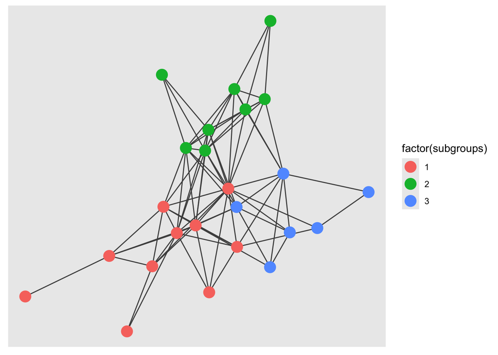

```r
collab_net %>%
  mutate(comp = group_components()) %>%
  filter(comp == 1) %>%
  mutate(subgroups = group_fast_greedy()) %>%
  ggraph(layout = "fr") +
  geom_edge_fan(
    width = .5,
    color = "grey30"
  ) +
  geom_node_point(
    aes(color = factor(subgroups)),
    size = 5
  )
```

Load attributes

```r
node_attributes <-
  here("data", "attributes.csv") %>%
  read_delim(delim = ";")
```

```
## ──────────────────────────────────────────────────────── Delimiter: ";" chr
## (5): id, education, gender, family, children dbl (7): ...1, age, age3,
## seniority, seniority_rec, soc_capital, satisfaction
```

```r
vertex_attr(collab_net) <- node_attributes
```

Plotting the network: cohesive subgroups, gender, seniority

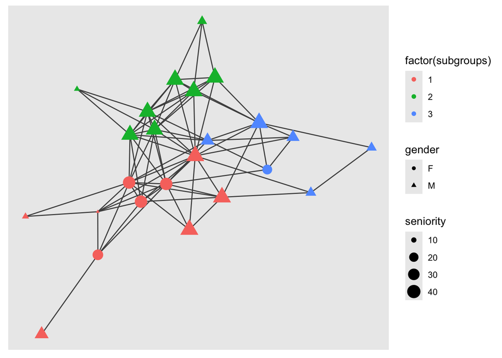

```r
collab_net %>%
  mutate(comp = group_components()) %>%
  filter(comp == 1) %>%
  mutate(subgroups = group_fast_greedy()) %>%
  ggraph(layout = "fr") +
  geom_edge_fan(
    width = .5,
    color = "grey30"
  ) +
  geom_node_point(
    aes(
      color = factor(subgroups),
      size = seniority,
      shape = gender
    )
  )
```

# 5 Example on ego-nets

- we’re going to work on the Sociable ego-network data (slightly modified)
- download files
- three files (show them):
  - egos’ attributes
  - alters’ attributes (no ego-alter list is needed because ego-alter ties are implicit in the alters’ file)
  - alter-alter edgelist with possible edge attributes

Node attributes

```r
(ego_attr <- read_csv2(file = here("data", "ego-class.csv")))
```

```
## ℹ Using "','" as decimal and "'.'" as grouping mark. Use `read_delim()` for more control.
```

| ego_id | random | age | gender | marital | educ | occ.typ | tel.int | dis.phys.count.cat | hcare.count.cat | adl.rec | gds.rec | demen | rsa | mmse |
| --- | --- | --- | --- | --- | --- | --- | --- | --- | --- | --- | --- | --- | --- | --- |
| 1 | No | 84 | Male | Not married | middle | 3. Retail/office employee | No | One | None | No | >1 | Yes | No | 30 |
| 2 | No | 81 | Male | Married | primary | 1. Elementary/menial | No | One | None | No | 0 | No | No | 28 |
| 3 | No | 83 | Male | Married | primary | 3. Retail/office employee | No | Multiple | None | No | 0 | No | No | 29 |
| 4 | No | 77 | Female | Married | primary | 1. Elementary/menial | No | One | None | No | >1 | No | No | 28 |
| 5 | No | 93 | Male | Married | primary | 1. Elementary/menial | No | Multiple | Multiple | No | 0 | No | No | 28 |
| 6 | Yes | 88 | Female | Married | primary | 2. Skilled crafts/trades | No | One | None | No | 0 | No | No | 29 |
| 7 | No | 81 | Male | Married | middle | 2. Skilled crafts/trades | No | One | One | No | 0 | No | No | 29 |
| 8 | No | 79 | Female | Married | middle | 2. Skilled crafts/trades | No | Multiple | One | No | 1 | No | No | 29 |
| 9 | No | 79 | Male | Married | primary | 2. Skilled crafts/trades | No | None | None | No | 0 | No | No | 28 |
| 10 | No | 84 | Male | Not married | middle | 2. Skilled crafts/trades | No | None | Multiple | No | 1 | No | No | 27 |

[output cut: 219 more lines]

Alters’ attributes

```r
(alter_attr <- read_csv(file = here("data", "alter-data.csv")))
```

| ego_id | alter_id | freq.rec | week.daily | alter.sex | alter.cores | role | role.rec | intgen |
| --- | --- | --- | --- | --- | --- | --- | --- | --- |
| 1 | 101 | yearly | No | Male | No | child | imm.fam | Yes |
| 1 | 102 | yearly | No | Male | No | child | imm.fam | Yes |
| 1 | 103 | yearly | No | Male | No | child | imm.fam | Yes |
| 1 | 104 | yearly | No | Male | No | child | imm.fam | Yes |
| 1 | 105 | yearly | No | Male | No | child | imm.fam | Yes |
| 1 | 106 | weekly | Yes | Female | No | child | imm.fam | Yes |
| 1 | 107 | daily | Yes | Female | No | oth.fam | ext.fam | No |
| 2 | 201 | daily | Yes | Female | Yes | spouse | imm.fam | No |
| 2 | 202 | daily | Yes | Male | Yes | child | imm.fam | Yes |
| 2 | 203 | weekly | Yes | Male | No | child | imm.fam | Yes |

[output cut: 2719 more lines]

Alter-alter ties

```r
(alter_alter <- read_csv(here("data", "alter-ties.csv")))
```

| ego_id | altsource_id | alttarg_id |
| --- | --- | --- |
| 1 | 101 | 102 |
| 1 | 101 | 103 |
| 1 | 101 | 104 |
| 1 | 101 | 105 |
| 1 | 101 | 106 |
| 1 | 102 | 103 |
| 1 | 102 | 104 |
| 1 | 102 | 105 |
| 1 | 102 | 106 |
| 1 | 103 | 104 |

[output cut: 8293 more lines]

- Research question: is network *complexity*, rather than size, beneficial for older adults’ cognitive abilities?
- We need to compute graph-level measures (complexity and size)
- We could code a loop that subsets `alter_alter` by `ego_id` and turn each ego-network into an `igraph` object

More efficient: creating an `egor` object and generating a list of igraph networks

```r
library(egor)

(
whole_df <-
  threefiles_to_egor(
    egos = ego_attr,
    alters.df = alter_attr,
    edges = alter_alter,
    ID.vars = list(
      ego = "ego_id",
      alter = "alter_id",
      source = "altsource_id",
      target = "alttarg_id"
    )
  )
)
```

```
## # EGO data (active): 229 × 15
##   .egoID random   age gender marital    educ  occ.typ tel.int dis.phys.count.cat
## *  <dbl> <chr>  <dbl> <chr>  <chr>      <chr> <chr>   <chr>   <chr>
## 1      1 No        84 Male   Not marri… midd… 3. Ret… No      One
## 2      2 No        81 Male   Married    prim… 1. Ele… No      One
## 3      3 No        83 Male   Married    prim… 3. Ret… No      Multiple
## 4      4 No        77 Female Married    prim… 1. Ele… No      One
## 5      5 No        93 Male   Married    prim… 1. Ele… No      Multiple
## # ℹ 224 more rows
## # ℹ 6 more variables: hcare.count.cat <chr>, adl.rec <chr>, gds.rec <chr>,
## #   demen <chr>, rsa <chr>, mmse <dbl>
## # ALTER data: 2,729 × 9
##   .altID .egoID freq.rec week.daily alter.sex alter.cores role  role.rec intgen
## *  <dbl>  <dbl> <chr>    <chr>      <chr>     <chr>       <chr> <chr>    <chr>
## 1    101      1 yearly   No         Male      No          child imm.fam  Yes
## 2    102      1 yearly   No         Male      No          child imm.fam  Yes
## 3    103      1 yearly   No         Male      No          child imm.fam  Yes
## # ℹ 2,726 more rows
## # AATIE data: 8,303 × 3
##   .egoID .srcID .tgtID
## *  <dbl>  <dbl>  <dbl>
## 1      1    101    102
## 2      1    101    103
## 3      1    101    104
## # ℹ 8,300 more rows
```

What kind of object is it?

Different parts can be inspected

```r
whole_df[[3]]
```

| .egoID | .srcID | .tgtID |
| --- | --- | --- |
| 1 | 101 | 102 |
| 1 | 101 | 103 |
| 1 | 101 | 104 |
| 1 | 101 | 105 |
| 1 | 101 | 106 |
| 1 | 102 | 103 |
| 1 | 102 | 104 |
| 1 | 102 | 105 |
| 1 | 102 | 106 |
| 1 | 103 | 104 |

[output cut: 8293 more lines]

Now we can easily convert all ego-networks into `igraph` objects

```r
graph_list <- as_igraph(whole_df)
```

As a list, we can inspect each ego network

```r
graph_list[[203]]
```

```
## IGRAPH be74ba1 UN-- 7 10 --
## + attr: .egoID (g/n), name (v/c), freq.rec (v/c), week.daily (v/c),
## | alter.sex (v/c), alter.cores (v/c), role (v/c), role.rec (v/c),
## | intgen (v/c)
## + edges from be74ba1 (vertex names):
##  [1] 20601--20602 20601--20603 20601--20604 20601--20605 20602--20603
##  [6] 20602--20604 20602--20605 20603--20604 20603--20605 20604--20605
```

Calculating size of ego-networks

```r
whole_df[[1]] <-
  whole_df[[1]] %>%
  mutate(net_size = map_int(graph_list, vcount))

whole_df[[1]] %>%
  summarise(
    mean_size = mean(net_size),
    sd_size = sd(net_size)
  )
```

| mean_size | sd_size |
| --- | --- |
| 11.91703 | 6.670643 |

Calculating number of *cohesive subgroups* in each ego-network through *Girvan-Newman* algorithm + integrating it into the `egor` object

```r
whole_df[[1]] <-
  whole_df[[1]] %>%
    mutate(
      clusters = graph_list %>%
        map_int(\(egonet)
          cluster_edge_betweenness(egonet) %>%
            length()
        )
    )

count(whole_df[[1]], clusters)
```

| clusters | n |
| --- | --- |
| 0 | 3 |
| 1 | 39 |
| 2 | 44 |
| 3 | 56 |
| 4 | 36 |
| 5 | 28 |
| 6 | 10 |
| 7 | 7 |
| 8 | 3 |
| 10 | 2 |

[output cut: 1 more lines]

Testing the hypothetical association between number of cohesive sub-groups and cognitive abilities on the Sociable dataset

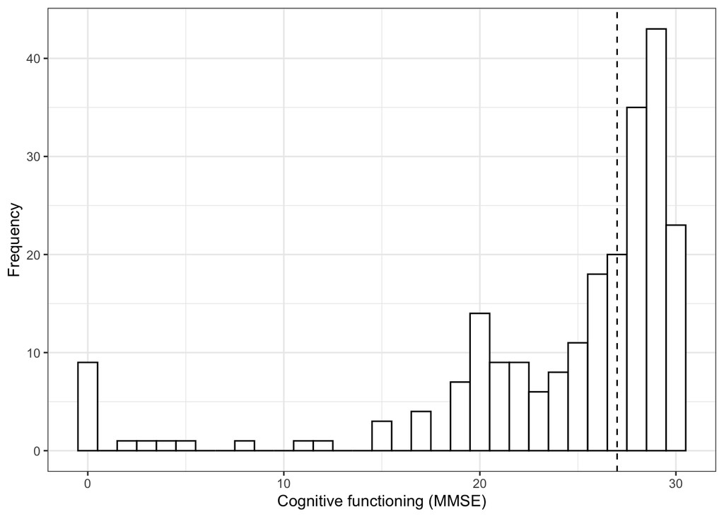

```r
whole_df[[1]] %>%
  ggplot(aes(mmse)) +
#  scale_fill_grey() +
  geom_histogram(binwidth = 1, color = "black", fill = "white") +
  geom_vline(xintercept = median(whole_df[[1]]$mmse, na.rm = T), color = "black", linetype = "dashed") +
  theme_bw() +
  labs(x = "Cognitive functioning (MMSE)", y = "Frequency")
```

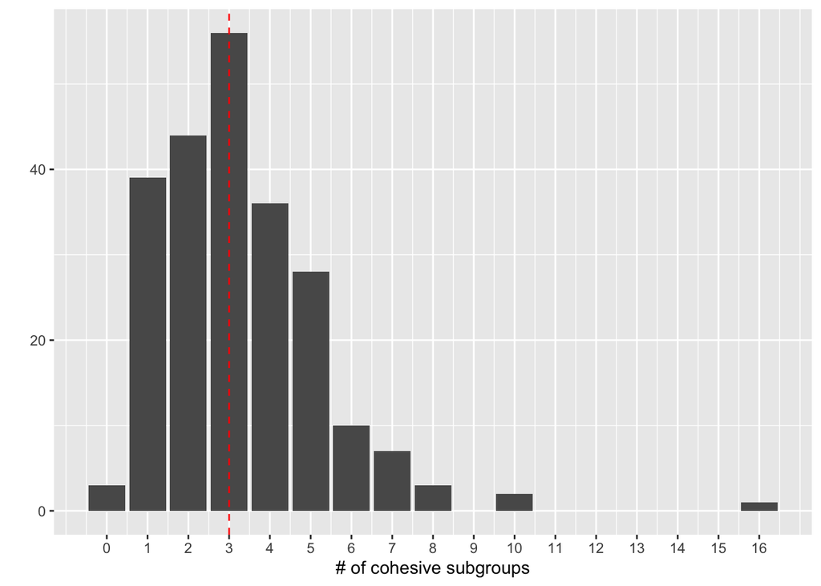

```r
whole_df[[1]] %>%
  ggplot(aes(clusters)) +
  geom_bar() +
  geom_vline(xintercept = median(whole_df[[1]]$clusters, na.rm = TRUE), color = "red", linetype = "dashed") +
  scale_x_continuous(breaks = 0:max(whole_df[[1]]$clusters)) +
  labs(y = "") +
  xlab("# of cohesive subgroups")
```

Association of MMSE with number of cohesive subgroups

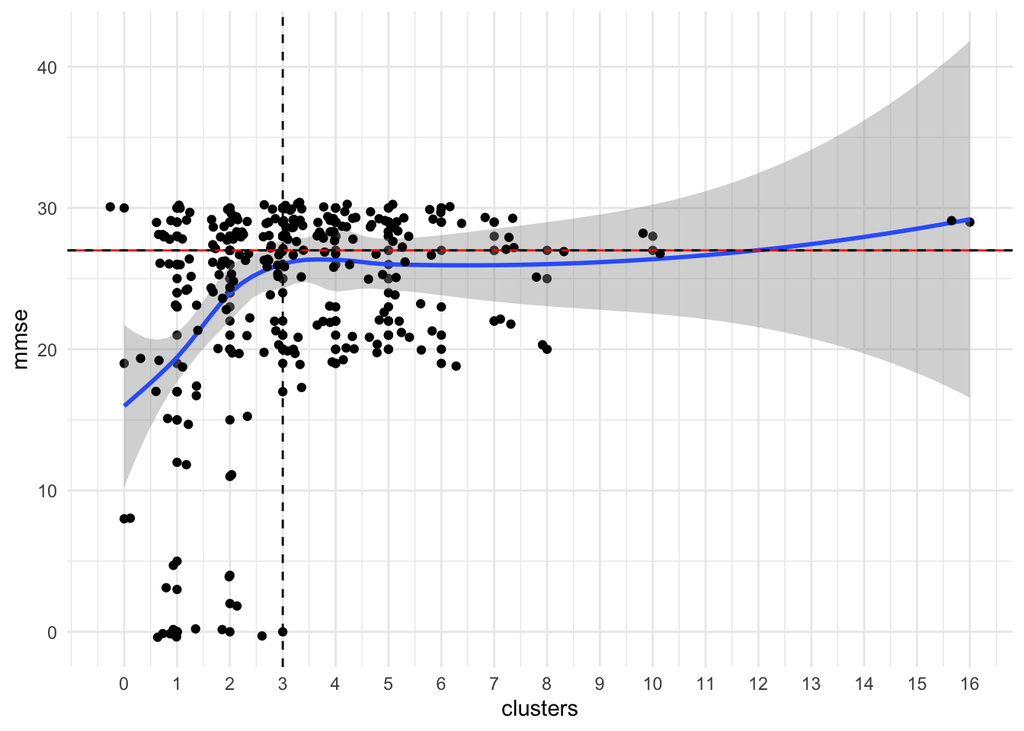

```r
whole_df[[1]] %>%
  ggplot(aes(clusters, mmse)) +
  geom_point() +
  geom_smooth() +
  geom_jitter() +
  scale_x_continuous(breaks = 0:16) +
  geom_hline(yintercept = 27, color = "red") +
  geom_hline(yintercept = median(whole_df[[1]]$mmse, na.rm = T), linetype = "dashed") +
  geom_vline(xintercept = median(whole_df[[1]]$clusters), linetype = "dashed") +
  theme_minimal()
```

```r
m <- mmse ~ clusters + net_size + age + educ + gender
ols <- lm(m, data = whole_df[[1]])
sjPlot::tab_model(ols, vcov.fun = "HC", show.se = TRUE)
```

|  | mmse |  |  |  |
| --- | --- | --- | --- | --- |
| Predictors | Estimates | std. Error | CI | p |
| (Intercept) | 37.01 | 8.02 | 21.21 – 52.80 | **<0.001** |
| clusters | 0.64 | 0.20 | 0.24 – 1.04 | **0.002** |
| net size | 0.11 | 0.07 | -0.03 – 0.25 | 0.116 |
| age | -0.18 | 0.09 | -0.36 – -0.01 | **0.042** |
| educ [middle] | -2.40 | 1.34 | -5.05 – 0.25 | 0.075 |
| educ [primary] | -1.83 | 1.09 | -3.98 – 0.32 | 0.094 |
| educ [uni or higher] | 1.08 | 1.19 | -1.25 – 3.42 | 0.361 |
| gender [Male] | 0.02 | 0.86 | -1.68 – 1.71 | 0.985 |
| Observations | 226 |  |  |  |
| R<sup>2</sup> / R<sup>2</sup> adjusted | 0.145 / 0.117 |  |  |  |

Visualize estimates

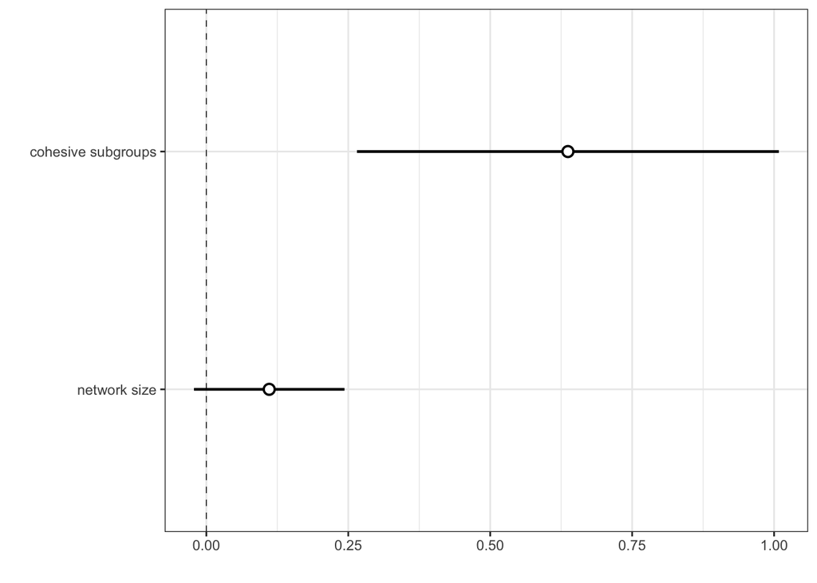

```r
p <- jtools::plot_summs(
  ols,
  coefs = c(
    "cohesive subgroups" = "clusters",
    "network size" = "net_size"
    # ,
    # "age" = "age",
    # "gender: male" = "gendermale",
    # "education: lower secondary" = "education2",
    # "education: higher secondary" = "education3",
    # "education: tertiary" = "education4",
    # "assisted living facility" = "rsa1",
    # "GDS > 1" = "gds.2yes"
  ),
  colors = "black",
  scale = F,
  robust = "HC"
  # ,
  # inner_ci_level = .9
  # ,
  # colors = "rainbow"
)
p +
  theme_bw() +
  labs(x = "", y = "")
```

# 6 Statistical inference

## 6.1 Case study: is there solidarity in my coworking space?

- We assume that support reciprocation is an obligation in case of high solidarity

For statistical inference we need a differet suite of packages

```r
library(statnet)
```

Creating a network object

```r
(support_net <-
  network(
    x = as_adjacency_matrix(sup_net),
    vertex.attr = node_attributes
  ))
```

```
##  Network attributes:
##   vertices = 29
##   directed = TRUE
##   hyper = FALSE
##   loops = FALSE
##   multiple = FALSE
##   bipartite = FALSE
##   total edges= 99
##     missing edges= 0
##     non-missing edges= 99
##
##  Vertex attribute names:
##     ...1 age age3 children education family gender id satisfaction seniority seniority_rec soc_capital vertex.names
##
## No edge attributes
```

Another way (provided the `intergraph` packages is installed):

```r
vertex_attr(sup_net) <- node_attributes
(support_net <- intergraph::asNetwork(sup_net))
```

```
##  Network attributes:
##   vertices = 29
##   directed = TRUE
##   hyper = FALSE
##   loops = FALSE
##   multiple = FALSE
##   bipartite = FALSE
##   total edges= 99
##     missing edges= 0
##     non-missing edges= 99
##
##  Vertex attribute names:
##     ...1 age age3 children education family gender id satisfaction seniority seniority_rec soc_capital vertex.names
##
## No edge attributes
```

Inspecting attributes

```r
support_net %v% "age"
```

```
##  [1] 40 41 25 28 28 31 39 28 31 28 33 52 31 27 31 31 32 31 34 40 28 31 24 27 31
## [26] 24 34 27 36
```

Different functions to get the usual descriptive metrics:

```r
gden(support_net)
```

```
## [1] 0.1219212
```

Some of them are masked by `igraph`:

```r
(indeg_sup <- sna::degree(support_net, gmode = "digraph", cmode = "indegree"))
```

```
##  [1] 4 6 3 4 1 5 1 2 2 7 0 5 7 2 7 5 3 0 5 5 1 2 2 2 7 1 6 2 2
```

Luckily, `ggraph` supports `network` objects:

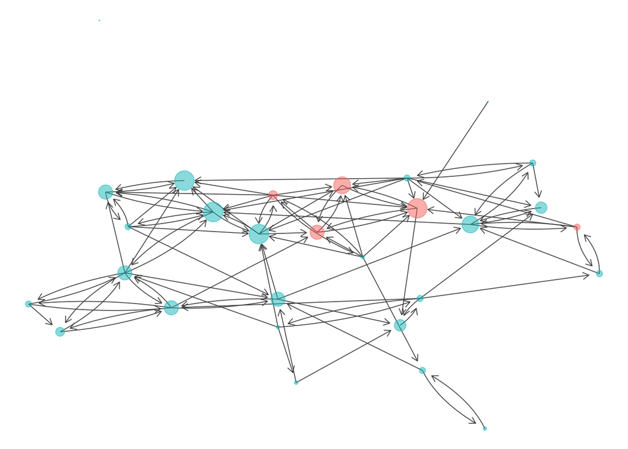

```r
support_net %>%
  ggraph(layout = "nicely") +
    geom_edge_fan(
    arrow = arrow(length = unit(2, "mm")),
    end_cap = circle(3, "mm"),
    color = "grey30",
    width = .3
  ) +
  geom_node_point(
    aes(color = gender),
    size = indeg_sup,
    alpha = .5,
    show.legend = FALSE
  ) +
  theme_void()
```

Let’s find the traces left by reciprocation in our network data.

Let’s count the complete dyads (i.e., pairs of nodes with reciprocal ties). Warning: the number of ties in those dyads is twice that of complete dyads!

```r
mutuality(support_net)
```

```
## Mut
##  25
```

What’s the state of the other dyads in the network?

```r
sna::dyad.census(support_net)
```

```
##      Mut Asym Null
## [1,]  25   49  332
```

What should we compare theses numbers to?

- fix number of nodes
- assume a data-generating process

```r
random_net <- rgraph(n = 29, m = 1, tprob = .5)
```

We then count the complete dyads in the generated random graph and compare it to the empirical network

```r
mutuality(random_net)
```

```
## Mut
## 102
```

Instead of just one instance of a random graph model, we generate a distribution of random graphs according to an E-R model with $p =$ 0.5.

```r
random_net <- rgraph(n = 29, m = 1000, tprob = .5)
```

Let’s compare the observed number of complete dyads with the distribution of complete dyads according to the model

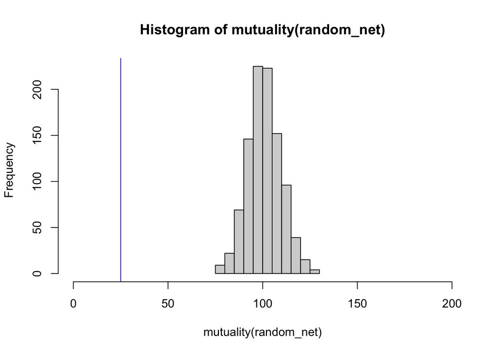

```r
hist(mutuality(random_net), xlim = c(0, 200))
abline(v = mutuality(support_net), col = "blue")
```

Let’s test reciprocation in our observed network against a more realistic distribution: an E-R model with *p* equal to the raw probability of ties to occur in our netork (i.e., the density)

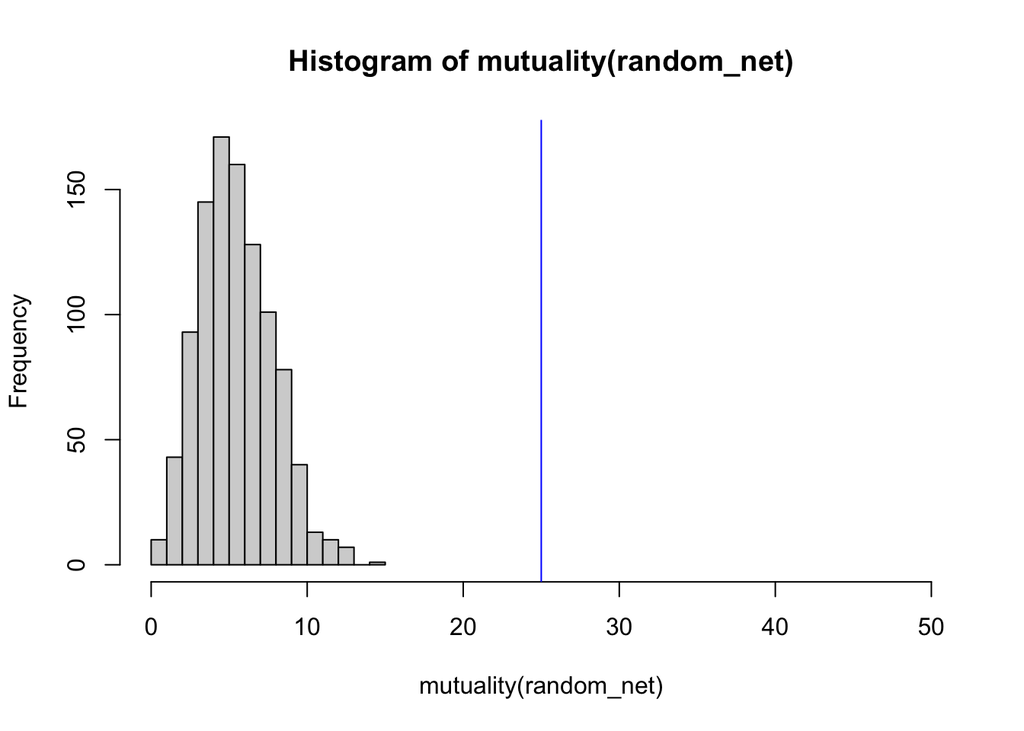

```r
random_net <- rgraph(n = 29, m = 1000, tprob = gden(support_net))
hist(mutuality(random_net), xlim = c(0, 50))
abline(v = mutuality(support_net), col = "blue")
```

All these models assume independent observations, while observing $x_{ij} \& x_{ji}$ is not independent on the observation of $x_{ij}$ or $x_{ji}$. We need a model that accounts for stochastic interdependencies between the data.

# 7 Exponential Random Graph Models

Specifying a baseline model

```r
m0 <- support_net ~ edges
summary(m0)
```

```
## edges
##    99
```

Fitting the model: MPLE is enough because the model doesn’t assume any interdependencies

```r
fit0 <- ergm(m0)
```

```
## Starting maximum pseudolikelihood estimation (MPLE):
```

```
## Obtaining the responsible dyads.
```

```
## Evaluating the predictor and response matrix.
```

```
## Maximizing the pseudolikelihood.
```

```
## Finished MPLE.
```

```
## Evaluating log-likelihood at the estimate.
```

```r
summary(fit0)
```

```
## Call:
## ergm(formula = m0)
##
## Maximum Likelihood Results:
##
##       Estimate Std. Error MCMC % z value Pr(>|z|)
## edges  -1.9744     0.1073      0  -18.41   <1e-04 ***
## ---
## Signif. codes:  0 '***' 0.001 '**' 0.01 '*' 0.05 '.' 0.1 ' ' 1
##
##      Null Deviance: 1125.7  on 812  degrees of freedom
##  Residual Deviance:  602.1  on 811  degrees of freedom
##
## AIC: 604.1  BIC: 608.8  (Smaller is better. MC Std. Err. = 0)
```

We can compute the odds-ratio from the log-odds

```r
coef(fit0)
```

```
##     edges
## -1.974362
```

```r
exp(coef(fit0)) / (1 + exp(coef(fit0)))
```

```
##     edges
## 0.1219212
```

It’s equal to the density of the network.

Dyadic independence model

```r
m1 <- update.formula(m0, . ~ . + mutual)
summary(m1)
```

```
##  edges mutual
##     99     25
```

Fitting now requires MCMCMLE

```r
fit1 <- ergm(m1)
```

```
## Starting maximum pseudolikelihood estimation (MPLE):
```

```
## Obtaining the responsible dyads.
```

```
## Evaluating the predictor and response matrix.
```

```
## Maximizing the pseudolikelihood.
```

```
## Finished MPLE.
```

```
## Starting Monte Carlo maximum likelihood estimation (MCMLE):
```

```
## Iteration 1 of at most 60:
```

```
## 1
```

```
## Optimizing with step length 1.0000.
```

```
## The log-likelihood improved by 0.0163.
```

[output not shown]

```r
summary(fit1)
```

```
## Call:
## ergm(formula = m1)
##
## Monte Carlo Maximum Likelihood Results:
##
##        Estimate Std. Error MCMC % z value Pr(>|z|)
## edges   -2.6059     0.1569      0 -16.605   <1e-04 ***
## mutual   2.6288     0.3523      0   7.462   <1e-04 ***
## ---
## Signif. codes:  0 '***' 0.001 '**' 0.01 '*' 0.05 '.' 0.1 ' ' 1
##
##      Null Deviance: 1125.7  on 812  degrees of freedom
##  Residual Deviance:  550.2  on 810  degrees of freedom
##
## AIC: 554.2  BIC: 563.6  (Smaller is better. MC Std. Err. = 0.76)
```

Markov model

```r
m2 <- update.formula(m1, . ~ . + twopath + gwesp(decay = .5, fixed = T))

## alternativa
#m2 <- support_net ~ edges + mutual + gwesp(.5, fixed = T) + gwdsp(.5, fixed = T)

fit2 <- ergm(m2)
```

```
## Starting maximum pseudolikelihood estimation (MPLE):
```

```
## Obtaining the responsible dyads.
```

```
## Evaluating the predictor and response matrix.
```

```
## Maximizing the pseudolikelihood.
```

```
## Finished MPLE.
```

```
## Starting Monte Carlo maximum likelihood estimation (MCMLE):
```

```
## Iteration 1 of at most 60:
```

[output not shown]

```r
summary(fit2)
```

```
## Call:
## ergm(formula = m2)
##
## Monte Carlo Maximum Likelihood Results:
##
##                     Estimate Std. Error MCMC % z value Pr(>|z|)
## edges               -2.23342    0.34409      0  -6.491   <1e-04 ***
## mutual               2.00211    0.35443      0   5.649   <1e-04 ***
## twopath             -0.24523    0.05625      0  -4.359   <1e-04 ***
## gwesp.OTP.fixed.0.5  1.07669    0.15227      0   7.071   <1e-04 ***
## ---
## Signif. codes:  0 '***' 0.001 '**' 0.01 '*' 0.05 '.' 0.1 ' ' 1
##
##      Null Deviance: 1125.7  on 812  degrees of freedom
##  Residual Deviance:  493.2  on 808  degrees of freedom
##
## AIC: 501.2  BIC: 520  (Smaller is better. MC Std. Err. = 1.373)
```

Let’s model degree distribution

```r
m3 <- update.formula(m2, . ~ . + gwidegree(.5, fixed = T) + gwodegree(.5, fixed = T))
fit3 <- ergm(m3)
```

```
## Starting maximum pseudolikelihood estimation (MPLE):
```

```
## Obtaining the responsible dyads.
```

```
## Evaluating the predictor and response matrix.
```

```
## Maximizing the pseudolikelihood.
```

```
## Finished MPLE.
```

```
## Starting Monte Carlo maximum likelihood estimation (MCMLE):
```

```
## Iteration 1 of at most 60:
```

[output not shown]

```r
summary(fit3)
```

```
## Call:
## ergm(formula = m3)
##
## Monte Carlo Maximum Likelihood Results:
##
##                     Estimate Std. Error MCMC % z value Pr(>|z|)
## edges               -2.07979    0.44223      0  -4.703   <1e-04 ***
## mutual               2.14735    0.44296      0   4.848   <1e-04 ***
## twopath             -0.25111    0.05879      0  -4.271   <1e-04 ***
## gwesp.OTP.fixed.0.5  1.02806    0.17033      0   6.036   <1e-04 ***
## gwideg.fixed.0.5    -0.64257    0.65093      0  -0.987    0.324
## gwodeg.fixed.0.5    -0.05031    0.77698      0  -0.065    0.948
## ---
## Signif. codes:  0 '***' 0.001 '**' 0.01 '*' 0.05 '.' 0.1 ' ' 1
##
##      Null Deviance: 1125.7  on 812  degrees of freedom
##  Residual Deviance:  494.1  on 806  degrees of freedom
##
## AIC: 506.1  BIC: 534.3  (Smaller is better. MC Std. Err. = 0.5511)
```

Correlation between node-level attributes and our network

```r
m4 <- update.formula(m2, . ~ . + absdiff("age") + nodeicov("age") + nodeocov("age"))
fit4 <- ergm(m4)
```

```
## Starting maximum pseudolikelihood estimation (MPLE):
```

```
## Obtaining the responsible dyads.
```

```
## Evaluating the predictor and response matrix.
```

```
## Maximizing the pseudolikelihood.
```

```
## Finished MPLE.
```

```
## Starting Monte Carlo maximum likelihood estimation (MCMLE):
```

```
## Iteration 1 of at most 60:
```

[output not shown]

```r
summary(fit4)
```

```
## Call:
## ergm(formula = m4)
##
## Monte Carlo Maximum Likelihood Results:
##
##                     Estimate Std. Error MCMC % z value Pr(>|z|)
## edges               -3.23295    0.73258      0  -4.413   <1e-04 ***
## mutual               2.12735    0.35956      0   5.916   <1e-04 ***
## twopath             -0.22760    0.05456      0  -4.172   <1e-04 ***
## gwesp.OTP.fixed.0.5  1.04272    0.15128      0   6.893   <1e-04 ***
## absdiff.age         -0.03129    0.01861      0  -1.681   0.0927 .
## nodeicov.age         0.04393    0.01780      0   2.468   0.0136 *
## nodeocov.age        -0.01038    0.01871      0  -0.555   0.5791
## ---
## Signif. codes:  0 '***' 0.001 '**' 0.01 '*' 0.05 '.' 0.1 ' ' 1
##
##      Null Deviance: 1125.7  on 812  degrees of freedom
##  Residual Deviance:  488.1  on 805  degrees of freedom
##
## AIC: 502.1  BIC: 535  (Smaller is better. MC Std. Err. = 0.7257)
```

Multiplexity

```r
m5 <- update.formula(m4, . ~ . + dyadcov(intergraph::asNetwork(collab_net)))
summary(ergm(m5))
```

```
## Starting maximum pseudolikelihood estimation (MPLE):
```

```
## Obtaining the responsible dyads.
```

```
## Evaluating the predictor and response matrix.
```

```
## Maximizing the pseudolikelihood.
```

```
## Finished MPLE.
```

```
## Starting Monte Carlo maximum likelihood estimation (MCMLE):
```

```
## Iteration 1 of at most 60:
```

[output not shown]

```
## Call:
## ergm(formula = m5)
##
## Monte Carlo Maximum Likelihood Results:
##
##                                                  Estimate Std. Error MCMC %
## edges                                            -4.87029    0.95494      0
## mutual                                            2.18463    0.61228      0
## twopath                                          -0.29619    0.05483      0
## gwesp.OTP.fixed.0.5                               0.87276    0.15730      0
## absdiff.age                                      -0.03253    0.02339      0
## nodeicov.age                                      0.06743    0.02097      0
## nodeocov.age                                      0.01545    0.02087      0
## dyadcov.intergraph::asNetwork(collab_net).mutual  3.48254    0.54774      0
## dyadcov.intergraph::asNetwork(collab_net).utri    2.25068    0.36573      0
## dyadcov.intergraph::asNetwork(collab_net).ltri    2.15149    0.37502      0
##                                                  z value Pr(>|z|)
## edges                                             -5.100  < 1e-04 ***
## mutual                                             3.568  0.00036 ***
## twopath                                           -5.402  < 1e-04 ***
## gwesp.OTP.fixed.0.5                                5.548  < 1e-04 ***
## absdiff.age                                       -1.391  0.16435
## nodeicov.age                                       3.216  0.00130 **
## nodeocov.age                                       0.740  0.45930
## dyadcov.intergraph::asNetwork(collab_net).mutual   6.358  < 1e-04 ***
## dyadcov.intergraph::asNetwork(collab_net).utri     6.154  < 1e-04 ***
## dyadcov.intergraph::asNetwork(collab_net).ltri     5.737  < 1e-04 ***
## ---
## Signif. codes:  0 '***' 0.001 '**' 0.01 '*' 0.05 '.' 0.1 ' ' 1
##
##      Null Deviance: 1125.7  on 812  degrees of freedom
##  Residual Deviance:  393.6  on 802  degrees of freedom
##
## AIC: 413.6  BIC: 460.6  (Smaller is better. MC Std. Err. = 0.753)
```